# Assignment for machine learning workshop 2018

## 1. Installing Anaconda

- Anaconda (https://www.anaconda.com/download)
  - single bundle includes most scientific computing packages.
  - make sure to pick version for **Python 3**.
  - easy install packages for Windows, Mac, Linux.
    - (single directory install)
- Jupyter (ipython notebooks)
  - Launch from *Anaconda Navigator*
  - browser-based interactive computing environment
    - development, documenting, executing code, viewing results
    - whole session stored in notebook document (.ipynb)
    - (also made and presented these slides!)

[figure not shown]

## 2. Introducing libraries

### (1) NumPy

- Library for multidimensional arrays and 2D matrices

```python
from numpy import *     # import all classes from numpy
a = arange(15)
a
```

```
array([ 0,  1,  2,  3,  4,  5,  6,  7,  8,  9, 10, 11, 12, 13, 14])
```

```python
b = a.reshape(3,5)
b
```

```
array([[ 0,  1,  2,  3,  4],
       [ 5,  6,  7,  8,  9],
       [10, 11, 12, 13, 14]])
```

```python
b.shape  # get the shape (num rows x num columns)
```

```
(3, 5)
```

- array creation and array operations

```python
a = array([1, 2, 3, 4])       # use a list to initialize
a
```

```
array([1, 2, 3, 4])
```

```python
b = array([[1.1,2,3], [4,5,6]]) # or list of lists
b
```

```
array([[1.1, 2. , 3. ],
       [4. , 5. , 6. ]])
```

- One-dimensional arrays are indexed, sliced, and iterated similar to Python lists.

```python
a = array([1,2,3,4,5])
a[2]
```

```
3
```

```python
a[2:5]            # index 2 through 4
```

```
array([3, 4, 5])
```

```python
# iterating with loop
for i in a:
    print(i)
```

```
1
2
3
4
5
```

### (2) pandas

- pandas is a Python library for data wrangling and analysis.
- `Dataframe` is a table of entries (like an Excel spreadsheet).
  - each column does not need to be the same type
  - operations to modify and operate on the table

```python
# setup pandas and display
import pandas as pd
```

```python
# read CSV file
dataset = pd.read_csv("kc_house_data.csv")

# print the first 5 rows of the dataframe
dataset.head(5)
```

|  | id | date | price | bedrooms | bathrooms | sqft_living | sqft_lot | floors | waterfront | view | ... | grade | sqft_above | sqft_basement | yr_built | yr_renovated | zipcode | lat | long | sqft_living15 | sqft_lot15 |
| --- | --- | --- | --- | --- | --- | --- | --- | --- | --- | --- | --- | --- | --- | --- | --- | --- | --- | --- | --- | --- | --- |
| 0 | 7129300520 | 20141013T000000 | 221900.0 | 3 | 1.00 | 1180 | 5650 | 1.0 | 0 | 0 | ... | 7 | 1180 | 0 | 1955 | 0 | 98178 | 47.5112 | -122.257 | 1340 | 5650 |
| 1 | 6414100192 | 20141209T000000 | 538000.0 | 3 | 2.25 | 2570 | 7242 | 2.0 | 0 | 0 | ... | 7 | 2170 | 400 | 1951 | 1991 | 98125 | 47.7210 | -122.319 | 1690 | 7639 |
| 2 | 5631500400 | 20150225T000000 | 180000.0 | 2 | 1.00 | 770 | 10000 | 1.0 | 0 | 0 | ... | 6 | 770 | 0 | 1933 | 0 | 98028 | 47.7379 | -122.233 | 2720 | 8062 |
| 3 | 2487200875 | 20141209T000000 | 604000.0 | 4 | 3.00 | 1960 | 5000 | 1.0 | 0 | 0 | ... | 7 | 1050 | 910 | 1965 | 0 | 98136 | 47.5208 | -122.393 | 1360 | 5000 |
| 4 | 1954400510 | 20150218T000000 | 510000.0 | 3 | 2.00 | 1680 | 8080 | 1.0 | 0 | 0 | ... | 8 | 1680 | 0 | 1987 | 0 | 98074 | 47.6168 | -122.045 | 1800 | 7503 |

5 rows × 21 columns

- select a column

```python
dataset['price']  #dataset.price
```

```
0         221900.0
1         538000.0
2         180000.0
3         604000.0
4         510000.0
5        1225000.0
6         257500.0
7         291850.0
8         229500.0
9         323000.0
10        662500.0
11        468000.0
12        310000.0
13        400000.0
14        530000.0
```

[output cut: 47 more lines]

- query the table # select the data according to some specific requirements (constraints)

```python
# select Age greater than 30
dataset[dataset.bedrooms > 10]
```

|  | id | date | price | bedrooms | bathrooms | sqft_living | sqft_lot | floors | waterfront | view | ... | grade | sqft_above | sqft_basement | yr_built | yr_renovated | zipcode | lat | long | sqft_living15 | sqft_lot15 |
| --- | --- | --- | --- | --- | --- | --- | --- | --- | --- | --- | --- | --- | --- | --- | --- | --- | --- | --- | --- | --- | --- |
| 8757 | 1773100755 | 20140821T000000 | 520000.0 | 11 | 3.00 | 3000 | 4960 | 2.0 | 0 | 0 | ... | 7 | 2400 | 600 | 1918 | 1999 | 98106 | 47.5560 | -122.363 | 1420 | 4960 |
| 15870 | 2402100895 | 20140625T000000 | 640000.0 | 33 | 1.75 | 1620 | 6000 | 1.0 | 0 | 0 | ... | 7 | 1040 | 580 | 1947 | 0 | 98103 | 47.6878 | -122.331 | 1330 | 4700 |

2 rows × 21 columns

# Ready to start!!!

```python
#Import Libraries
import numpy as np
import pandas as pd
import matplotlib.pyplot as plt
%matplotlib inline
```

# Dataset

This dataset contains house sale prices for King County, which includes Seattle. It includes homes sold between May 2014 and May 2015.

It's a great dataset for evaluating simple regression models.

```python
#Importing DataSet
dataset = pd.read_csv("kc_house_data.csv")
```

19 house features plus the price and the id columns, along with 21613 observations.

1. **id** a notation for a house
2. **date** Date house was sold
3. **price** Price is prediction target
4. **bedrooms** Number of Bedrooms/House
5. **bathrooms** Number of bathrooms/bedrooms
6. **sqft_living** square footage of the home
7. **sqft_lot** square footage of the lot
8. **floors** Total floors (levels) in house
9. **waterfront** House which has a view to a waterfront
10. **view** Has been viewed
11. **condition** How good the condition is ( Overall )
12. **grade** overall grade given to the housing unit, based on King County grading system
13. **sqft_above** square footage of house apart from basement
14. **sqft_basement** square footage of the basement
15. **yr_built** Built Year
16. **yr_renovated** Year when house was renovated
17. **zipcode** zip
18. **lat** Latitude coordinate
19. **long** Longitude coordinate
20. **sqft_living15** Living room area in 2015(implies-- some renovations) This might or might not have affected the lotsize area
21. **sqft_lot15** lotSize area in 2015(implies-- some renovations)

```python
dataset.head(5)
```

|  | id | date | price | bedrooms | bathrooms | sqft_living | sqft_lot | floors | waterfront | view | ... | grade | sqft_above | sqft_basement | yr_built | yr_renovated | zipcode | lat | long | sqft_living15 | sqft_lot15 |
| --- | --- | --- | --- | --- | --- | --- | --- | --- | --- | --- | --- | --- | --- | --- | --- | --- | --- | --- | --- | --- | --- |
| 0 | 7129300520 | 20141013T000000 | 221900.0 | 3 | 1.00 | 1180 | 5650 | 1.0 | 0 | 0 | ... | 7 | 1180 | 0 | 1955 | 0 | 98178 | 47.5112 | -122.257 | 1340 | 5650 |
| 1 | 6414100192 | 20141209T000000 | 538000.0 | 3 | 2.25 | 2570 | 7242 | 2.0 | 0 | 0 | ... | 7 | 2170 | 400 | 1951 | 1991 | 98125 | 47.7210 | -122.319 | 1690 | 7639 |
| 2 | 5631500400 | 20150225T000000 | 180000.0 | 2 | 1.00 | 770 | 10000 | 1.0 | 0 | 0 | ... | 6 | 770 | 0 | 1933 | 0 | 98028 | 47.7379 | -122.233 | 2720 | 8062 |
| 3 | 2487200875 | 20141209T000000 | 604000.0 | 4 | 3.00 | 1960 | 5000 | 1.0 | 0 | 0 | ... | 7 | 1050 | 910 | 1965 | 0 | 98136 | 47.5208 | -122.393 | 1360 | 5000 |
| 4 | 1954400510 | 20150218T000000 | 510000.0 | 3 | 2.00 | 1680 | 8080 | 1.0 | 0 | 0 | ... | 8 | 1680 | 0 | 1987 | 0 | 98074 | 47.6168 | -122.045 | 1800 | 7503 |

5 rows × 21 columns

```python
price = dataset['price']
price = np.array(price) # transfer the dataframe type to numpy array type
features = dataset.iloc[:, 3:21]
```

```python
features.head(5)
```

|  | bedrooms | bathrooms | sqft_living | sqft_lot | floors | waterfront | view | condition | grade | sqft_above | sqft_basement | yr_built | yr_renovated | zipcode | lat | long | sqft_living15 | sqft_lot15 |
| --- | --- | --- | --- | --- | --- | --- | --- | --- | --- | --- | --- | --- | --- | --- | --- | --- | --- | --- |
| 0 | 3 | 1.00 | 1180 | 5650 | 1.0 | 0 | 0 | 3 | 7 | 1180 | 0 | 1955 | 0 | 98178 | 47.5112 | -122.257 | 1340 | 5650 |
| 1 | 3 | 2.25 | 2570 | 7242 | 2.0 | 0 | 0 | 3 | 7 | 2170 | 400 | 1951 | 1991 | 98125 | 47.7210 | -122.319 | 1690 | 7639 |
| 2 | 2 | 1.00 | 770 | 10000 | 1.0 | 0 | 0 | 3 | 6 | 770 | 0 | 1933 | 0 | 98028 | 47.7379 | -122.233 | 2720 | 8062 |
| 3 | 4 | 3.00 | 1960 | 5000 | 1.0 | 0 | 0 | 5 | 7 | 1050 | 910 | 1965 | 0 | 98136 | 47.5208 | -122.393 | 1360 | 5000 |
| 4 | 3 | 2.00 | 1680 | 8080 | 1.0 | 0 | 0 | 3 | 8 | 1680 | 0 | 1987 | 0 | 98074 | 47.6168 | -122.045 | 1800 | 7503 |

## Select features

You can see there are some many features in this dataset and we could choose any one of them to be our predictor variable (regressor), or more than one. Actually you could try any combination of features as our input data. For example, we could use **sqft_living** as our input to predict the price, or **bathrooms** and **sqft_living** to do our regression.

But how to choose a suitable variable as input? Perhaps start with choosing the one which is likely to have a linear relationship with price is the best. So we could visualize it first:

```python
dataset['price'] = price
```

Run following codes to draw scatter plots to find the relationship of every variable and price.

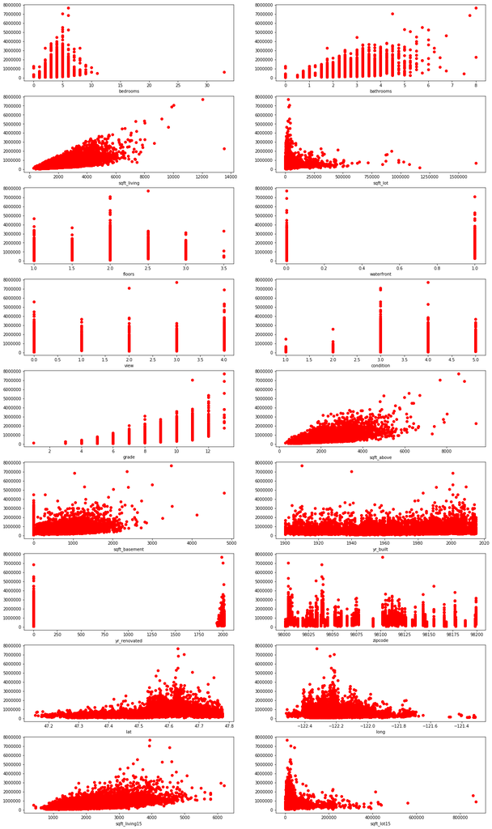

```python
plt.figure(figsize=(20,40))

for i in range(18):
    tmpX = np.array(features.iloc[:,i]).reshape(-1, 1)

    plt.subplot(10,2,i+1)
    plt.scatter(tmpX, price, color= 'red')
    plt.xlabel(dataset.keys()[3+i])
```

## Simple linear regression

- Linear regression with one variable.
  - Here we use **sqft_living**, which is the square footage of the home, as our variable.

```python
space=dataset['sqft_living']
price=dataset['price']

x = np.array(space).reshape(-1, 1)
y = np.array(price)
```

## Split training/test data

```python
#Splitting the data into Train and Test
from sklearn.cross_validation import train_test_split

# randomly split data into 50% train and 50% test set
xtrain, xtest, ytrain, ytest = train_test_split(x, y, train_size=0.5, test_size=0.5, random_state=4487)
```

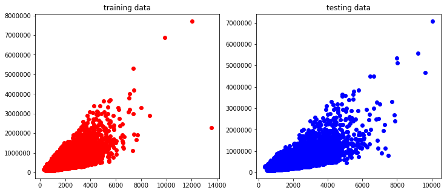

```python
# view train & test data
plt.figure(figsize=(12,5))

plt.subplot(1,2,1)   # put two subplots in the same figure
# scatter plot - Y value selects the color
plt.scatter(xtrain, ytrain, color= 'red')
plt.title('training data')

plt.subplot(1,2,2)
plt.scatter(xtest, ytest, color= 'blue')
plt.title('testing data')

plt.show()
```

## Learning Process

```python
#Fitting simple linear regression to the Training Set
from sklearn.linear_model import LinearRegression
```

## Prediction

```python
#Predicting the prices
```

## Visualization

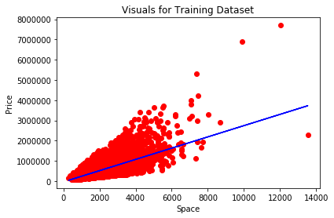

```python
#Visualizing the training Test Results
plt.scatter(xtrain, ytrain, color= 'red')
plt.plot(xtrain, regressor.predict(xtrain), color = 'blue')
plt.title ("Visuals for Training Dataset")
plt.xlabel("Space")
plt.ylabel("Price")

plt.show()
```

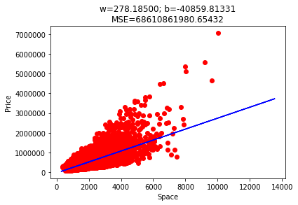

```python
#Visualizing the Test Results
from sklearn.metrics import mean_squared_error

plt.scatter(xtest, ytest, color= 'red')
plt.plot(xtrain, regressor.predict(xtrain), color = 'blue')


# calculate mean-square error on training set
MSE = mean_squared_error(ytest, regressor.predict(xtest))

plt.title("w={:.5f}; b={:.5f}\nMSE={:.5f}".format(float(regressor.coef_), float(regressor.intercept_), MSE))
plt.xlabel("Space")
plt.ylabel("Price")
plt.show()
```

# Multiple linear regression

## Split training/test data

```python
from mpl_toolkits import mplot3d # enable 3d plot
```

```
Text(0.5,0,'bedrooms')
```

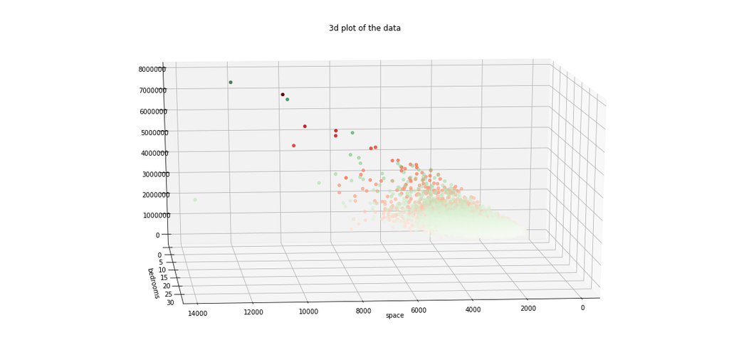

```python
# Visualize
plt.figure(figsize=(20,10))
ax = plt.axes(projection='3d')
ax.scatter(xtrain[:,0], xtrain[:,1], ytrain, c=ytrain,cmap='Greens')
ax.scatter(xtest[:,0], xtest[:,1], ytest, c=ytest,cmap='Reds')
ax.view_init(15, 85)
ax.set_title('3d plot of the data');
ax.set_xlabel('space')
ax.set_ylabel('bedrooms')
```

```python
#Fitting simple linear regression to the Training Set
```

[output not shown]

```python
#Predicting the prices
```

```python
regressor.coef_
```

```
array([   305.67236922, -47262.13306052])
```

```python
regressor.intercept_
```

```
61346.718928723014
```

```python
#print("y =" + str(regressor.coef_[0]) + "*x1 + " + str(regressor.coef_[1]) + " *x2 + " + str(regressor.intercept_))
```